# Sampling in R

Claudia Czado

15 April, 2020

## Required R packages

- rafalib
- mosaic
- dplyr
- ggplot2

## Flipping coins

using the R packages

- mosaic,
- dplyr and
- ggplot2

### Flipping a single fair coin

```r
set.seed(2017)
do(1) * rflip(1)
```

```
##   n heads tails prop
## 1 1     1     0    1
```

### Flipping 6 times 10 fair coins independently

```r
do(6) * rflip(10)
```

```
##    n heads tails prop
## 1 10     4     6  0.4
## 2 10     5     5  0.5
## 3 10     5     5  0.5
## 4 10     7     3  0.7
## 5 10     5     5  0.5
## 6 10     7     3  0.7
```

### Flipping 5000 times 5 fair coins independently

```r
simGuesses <- do(5000) * rflip(5)
```

Sorting the 5000 5 coin flips by the number of heads

```r
simGuesses %>%
  group_by(heads) %>%
  summarize(count = n())
```

```
## # A tibble: 6 x 2
##   heads count
##   <dbl> <int>
## 1     0   163
## 2     1   750
## 3     2  1575
## 4     3  1590
## 5     4   756
## 6     5   166
```

### Creating a histogram of the number of heads resulting from the 5000 flips

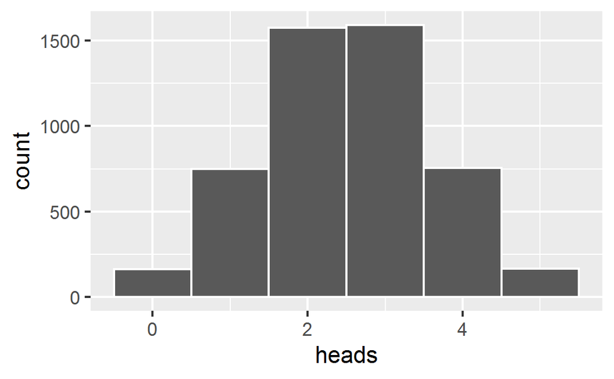

```r
ggplot(data = simGuesses, mapping = aes(x = heads)) +
  geom_histogram(binwidth = 1, color = "white")
```

This histogram does not reflect the disceteness of the number of heads

### Histogram accounting for disceteness of the number of heads

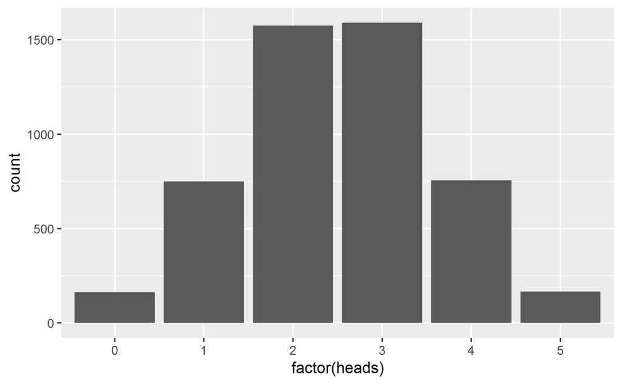

```r
ggplot(data = simGuesses, mapping = aes(x = factor(heads))) +
  geom_bar()
```

## Sampling from standard univariate distributions

The function

- *runif()* samples from a uniform distribution
- *rbinom()* samples from a binomial distribution
- *rpois()* samples from a Poisson distribution
- *rgamma()* samples from a Gamma distribution
- *rexp()* samples from an exponential distribution
- *rnorm()* samples from a Normal distribution

### Sampling from the uniform and the normal distribution

We now sample from some distributions for several sample sizes

```r
data.unif100<-runif(100,min=0,max=1)
data.unif200<-runif(200,min=0,max=1)
data.unif500<-runif(500,min=0,max=1)
data.unif1000<-runif(1000,min=0,max=1)

data.norm100<-rnorm(100,mean=0,sd=1)
data.norm200<-rnorm(200,mean=0,sd=1)
data.norm500<-rnorm(500,mean=0,sd=1)
data.norm1000<-rnorm(1000,mean=0,sd=1)

data.exp100<-rexp(100,rate=1)
data.exp200<-rexp(200,rate=1)
data.exp500<-rexp(500,rate=1)
data.exp1000<-rexp(1000,rate=1)
```

### Histograms of the sampled uniformly distributed values

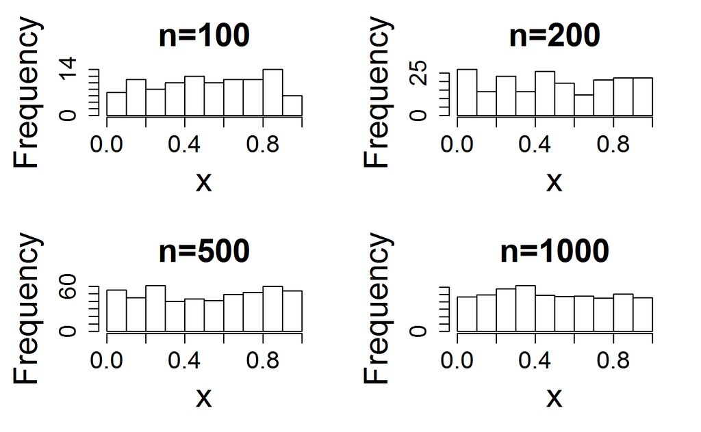

```r
bigpar(2,2)
hist(data.unif100,xlab="x",main="n=100")
hist(data.unif200,xlab="x",main="n=200")
hist(data.unif500,xlab="x",main="n=500")
hist(data.unif1000,xlab="x",main="n=1000")
```

### Histograms of the sampled exponentially distributed values

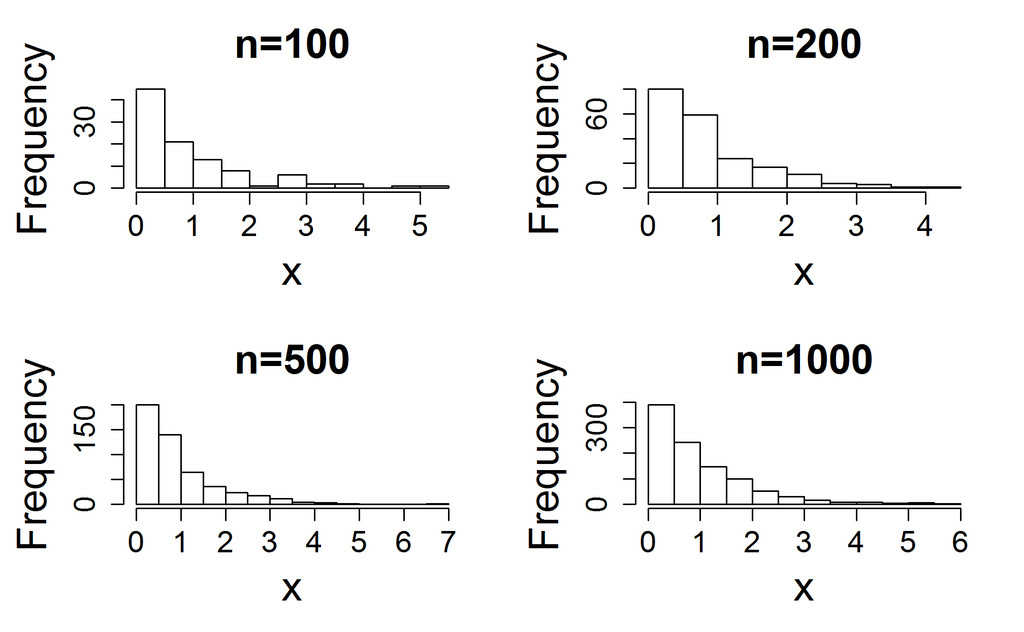

```r
bigpar(2,2)
hist(data.exp100,xlab="x",main="n=100")
hist(data.exp200,xlab="x",main="n=200")
hist(data.exp500,xlab="x",main="n=500")
hist(data.exp1000,xlab="x",main="n=1000")
```

### Histograms of the sampled normally distributed values

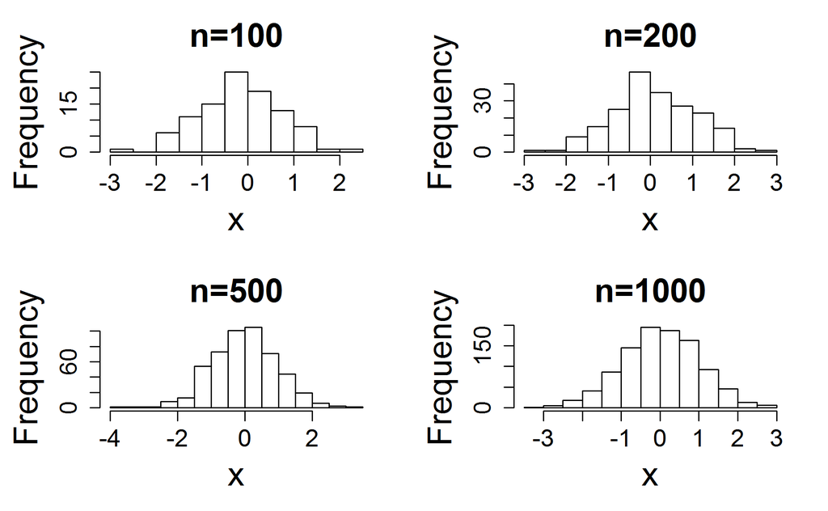

```r
bigpar(2,2)
hist(data.norm100,xlab="x",main="n=100")
hist(data.norm200,xlab="x",main="n=200")
hist(data.norm500,xlab="x",main="n=500")
hist(data.norm1000,xlab="x",main="n=1000")
```

### QQ plots of the normally distributed samples

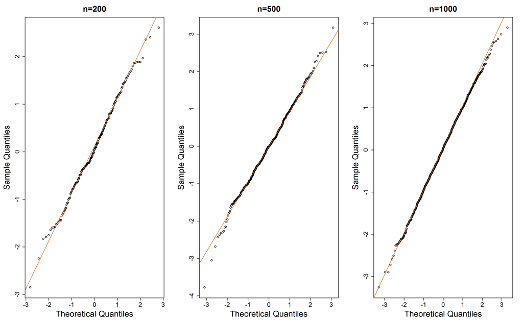

```r
bigpar(1,3)
qqnorm(data.norm200,main="n=200")
qqline(data.norm200,col=2)
qqnorm(data.norm500,main="n=500")
qqline(data.norm500,col=2)
qqnorm(data.norm1000,main="n=1000")
qqline(data.norm1000,col=2)
```

### Further R functions for distributions

Similarly for all the other distributions

### Probability integral transforms (PIT) of normal and exponential samples

```r
udata.exp100<-pexp(data.exp100)
udata.exp200<-pexp(data.exp200)
udata.exp500<-pexp(data.exp500)
udata.exp1000<-pexp(data.exp1000)

udata.norm100<-pnorm(data.norm100)
udata.norm200<-pnorm(data.norm200)
udata.norm500<-pnorm(data.norm500)
udata.norm1000<-pnorm(data.norm1000)
```

### Histograms of PIT’s of normally distributed samples

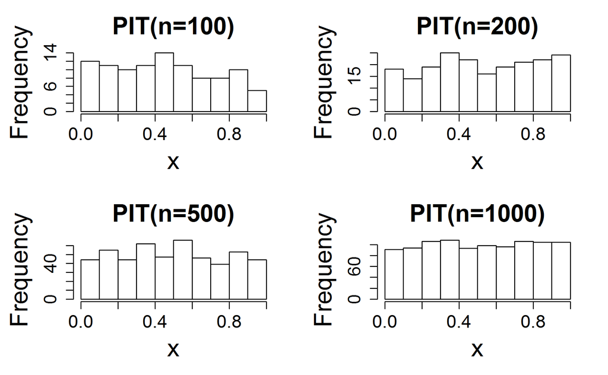

```r
bigpar(2,2)
hist(udata.norm100,xlab="x",main="PIT(n=100)")
hist(udata.norm200,xlab="x",main="PIT(n=200)")
hist(udata.norm500,xlab="x",main="PIT(n=500)")
hist(udata.norm1000,xlab="x",main="PIT(n=1000)")
```

### Histograms of PIT’s of exponentially distributed samples

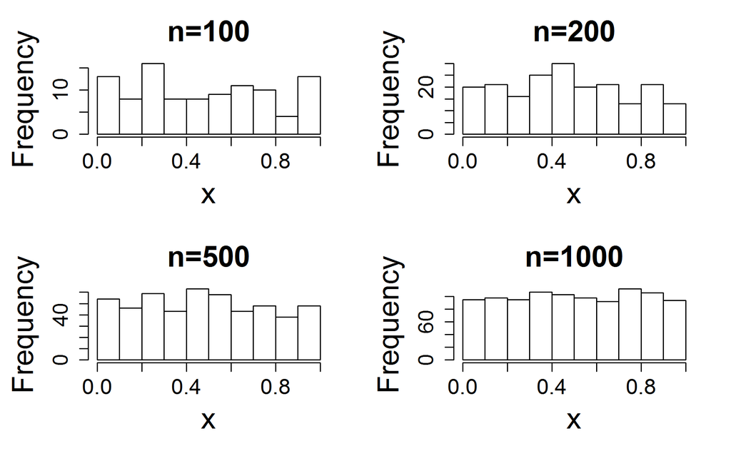

```r
bigpar(2,2)
hist(udata.exp100,xlab="x",main="n=100")
hist(udata.exp200,xlab="x",main="n=200")
hist(udata.exp500,xlab="x",main="n=500")
hist(udata.exp1000,xlab="x",main="n=1000")
```